# Aumento do Faturamento da Empresa com Previsão de Churn

## *Antes de mais nada, vou explicar de forma breve o que é Churn, e todos seus conceitos envolvidos. Vamos lá!*

# O que é churn?

Churn é a medida de quantos clientes param de usar um produto. Isso pode ser medido com base no uso real ou falha na renovação (quando o produto é vendido usando um modelo de assinatura). Frequentemente avaliada por um período de tempo específico, pode haver uma taxa de churn mensal, trimestral ou anual.

Quando novos clientes começam a comprar e/ou usar um produto, cada novo usuário contribui para a taxa de crescimento do produto. Inevitavelmente, alguns desses clientes acabarão por descontinuar a sua utilização ou cancelar a sua subscrição; ou porque mudaram para um concorrente ou solução alternativa, não precisam mais das funções do produto, estão insatisfeitos com a experiência do usuário ou não podem mais arcar ou justificar o custo. Os clientes que param de usar/pagar são o “churn” por um determinado período de tempo.

# Como é calculado o Churn?

Em sua forma mais simplista, a taxa de cancelamento é a porcentagem do total de clientes que param de usar/pagar durante um período de tempo. Assim, se houvesse 10.000 clientes totais em março e 1.000 deles deixassem de ser clientes, a taxa de churn mensal seria de 10%.

[figure not shown]

# Por que o Churn ocorre?

Muitos fatores influenciam as razões de um cliente para o Churn. Pode ser o fato de haver um novo concorrente no mercado oferecendo preços melhores ou talvez o serviço que eles estão recebendo não esteja à altura, e assim por diante. Portanto, não há uma resposta correta sobre por que exatamente o cliente deseja churn, porque, como você pode ver, há muitos fatores que influenciam.

# Prós e Contras da Taxa de Churn

| Prós | Contras |
| --- | --- |
| Fornece clareza sobre a qualidade do negócio | Não fornece clareza sobre os tipos de clientes que saem: novos versus antigos |
| Indica se os clientes estão satisfeitos ou insatisfeitos com o produto ou serviço | Não diferencia os tipos de empresas na comparação do setor: startups, em crescimento e consolidadas |
| Permite a comparação com concorrentes para medir um nível aceitável de churn |  |
| Fácil de calcular |  |

#### O trabalho de um cientista de dados é encontrar esses padrões nos dados fornecidos e ver quais fatos são produzidos durante a análise de dados.

### Diante disso, vamos para o problema de negócio e contextuar a situação ao Churn Rate.

## Empresa TopBank

#### *a descrição a seguir é totalmente fictícia, apenas contextualização para um problema de negócio.*

A TopBank é uma grande empresa de serviços bancários. Ela atua principalmente nos países da Europa oferecendo produtos financeiros, desde contas bancárias até investimentos, passando por alguns tipos de seguros e produto de investimento.

O modelo de negócio da empresa é do tipo serviço, ou seja, ela comercializa serviços bancários para seus clientes através de agências físicas e um portal online.

O principal produto da empresa é uma conta bancária, na qual o cliente pode depositar seu salário, fazer saques, depósitos e transferência para outras contas. Essa conta bancária não tem custo para o cliente e tem uma vigência de 12 meses, ou seja, o cliente precisa renovar o contrato dessa conta para continuar utilizando pelos próximos 12 meses.

Segundo o time de Analytics da TopBank, cada cliente que possui essa conta bancária retorna um valor monetário de 15% do valor do seu salário estimado, se esse for menor que a média e 20% se esse salário for maior que a média, durante o período vigente de sua conta. Esse valor é calculado anualmente.

Por exemplo, se o salário mensal de um cliente é de 1.000,00 e a média de todos os salários do banco é de 800,00. A empresa, portanto, fatura 200,00 anualmente com esse cliente. Se esse cliente está no banco há 10 anos, a empresa já faturou 2.000,00 com suas transações e utilização da conta. (*Valores em reais*).

Nos últimos meses, o time de Analytics percebeu que a taxa de clientes cancelando suas contas e deixando o banco, atingiu números inéditos na empresa. Preocupados com o aumento dessa taxa, o time planejou um plano de ação para diminuir taxa de evasão de clientes.

Preocupados com a queda dessa métrica, o time de Analytics da TopBottom, contratou você como consultor de Data Science para criar um plano de ação, com o objetivo de reduzir a evasão de clientes, ou seja, impedir que o cliente cancele seu contrato e não o renove por mais 12 meses. Essa evasão, nas métricas de negócio, é conhecida como Churn.

De maneira geral, Churn é uma métrica que indica o número de clientes que cancelaram o contrato ou pararam de comprar seu produto em um determinado período de tempo. Por exemplo, clientes que cancelaram o contrato de serviço ou após o vencimento do mesmo, não renovaram, são clientes considerados em churn.

Outro exemplo seria os clientes que não fazem uma compra à mais de 60 dias. Esse clientes podem ser considerados clientes em churn até que uma compra seja realizada. O período de 60 dias é totalmente arbitrário e varia entre empresas.

## O Desafio

Como um Consultor de Ciência de Dados, criarei um plano de ação para diminuir o número de clientes em churn e mostrar o retorno financeiro da sua solução.

Ao final da consultoria, entregarei ao CEO da TopBottom um modelo em produção, que receberá uma base de clientes via API e retornará essa mesma base “scorada”, ou seja, um coluna à mais com a probabilidade de cada cliente entrar em churn.

Além disso, você precisará fornecer um relatório reportando a performance do seu modelo e o impacto financeiro da sua solução. Questões que o CEO e o time de Analytics gostariam de ver em seu relatório:

1. Qual a taxa atual de Churn da TopBank? Como ela varia mensalmente?
2. Qual a Performance do modelo em classificar os clientes como churns?
3. Qual o retorno esperado, em termos de faturamento, se a empresa utilizar seu modelo para evitar o churn dos clientes?
4. Uma possível ação para evitar que o cliente entre em churn é oferecer um cupom de desconto, ou alguma outro incentivo financeiro para ele renovar seu contrato por mais 12 meses.

# Dicionário de dados

Cada linha representa um cliente e cada coluna contém alguns atributos que descrevem esse cliente. O conjunto de dados inclui informações sobre:

```python
# Instala pacotes
!pip install -q pycaret --user
!pip install -q sweetviz --user
!pip install -q autoviz --user
!pip install -q gradio --user
```

```python
# Carregando as bibliotecas

import time
import sklearn
import datetime
import pandas as pd
import numpy as np
import matplotlib as m
import matplotlib.pyplot as plt
import seaborn as sns
import warnings
from pycaret.classification import *
warnings.filterwarnings("ignore")
```

```python
# Carrega o dataset
df1 = pd.read_csv("churn.csv", encoding = 'utf-8')
```

```python
# Verifica o shape
df1.shape
```

```
(10000, 14)
```

```python
# Visualiza os dados
df1.head()
```

|  | RowNumber | CustomerId | Surname | CreditScore | Geography | Gender | Age | Tenure | Balance | NumOfProducts | HasCrCard | IsActiveMember | EstimatedSalary | Exited |
| --- | --- | --- | --- | --- | --- | --- | --- | --- | --- | --- | --- | --- | --- | --- |
| 0 | 1 | 15634602 | Hargrave | 619 | France | Female | 42 | 2 | 0.00 | 1 | 1 | 1 | 101348.88 | 1 |
| 1 | 2 | 15647311 | Hill | 608 | Spain | Female | 41 | 1 | 83807.86 | 1 | 0 | 1 | 112542.58 | 0 |
| 2 | 3 | 15619304 | Onio | 502 | France | Female | 42 | 8 | 159660.80 | 3 | 1 | 0 | 113931.57 | 1 |
| 3 | 4 | 15701354 | Boni | 699 | France | Female | 39 | 1 | 0.00 | 2 | 0 | 0 | 93826.63 | 0 |
| 4 | 5 | 15737888 | Mitchell | 850 | Spain | Female | 43 | 2 | 125510.82 | 1 | 1 | 1 | 79084.10 | 0 |

## Análise exploratória

Vamos explorar os dados para compreender as relações e influências ou não entre as variáveis dependentes e alvo.

```python
# Verifica valores unicos
df1.nunique()
```

```
RowNumber          10000
CustomerId         10000
Surname             2932
CreditScore          460
Geography              3
Gender                 2
Age                   70
Tenure                11
Balance             6382
NumOfProducts          4
HasCrCard              2
IsActiveMember         2
EstimatedSalary     9999
Exited                 2
dtype: int64
```

```python
df1.isnull().sum()
```

```
RowNumber          0
CustomerId         0
Surname            0
CreditScore        0
Geography          0
Gender             0
Age                0
Tenure             0
Balance            0
NumOfProducts      0
HasCrCard          0
IsActiveMember     0
EstimatedSalary    0
Exited             0
dtype: int64
```

```python
# Tipos de dados
df1.dtypes
```

```
RowNumber            int64
CustomerId           int64
Surname             object
CreditScore          int64
Geography           object
Gender              object
Age                  int64
Tenure               int64
Balance            float64
NumOfProducts        int64
HasCrCard            int64
IsActiveMember       int64
EstimatedSalary    float64
Exited               int64
dtype: object
```

```python
# Resumo das colunas numéricas
df1.describe()
```

|  | RowNumber | CustomerId | CreditScore | Age | Tenure | Balance | NumOfProducts | HasCrCard | IsActiveMember | EstimatedSalary | Exited |
| --- | --- | --- | --- | --- | --- | --- | --- | --- | --- | --- | --- |
| count | 10000.00000 | 1.000000e+04 | 10000.000000 | 10000.000000 | 10000.000000 | 10000.000000 | 10000.000000 | 10000.00000 | 10000.000000 | 10000.000000 | 10000.000000 |
| mean | 5000.50000 | 1.569094e+07 | 650.528800 | 38.921800 | 5.012800 | 76485.889288 | 1.530200 | 0.70550 | 0.515100 | 100090.239881 | 0.203700 |
| std | 2886.89568 | 7.193619e+04 | 96.653299 | 10.487806 | 2.892174 | 62397.405202 | 0.581654 | 0.45584 | 0.499797 | 57510.492818 | 0.402769 |
| min | 1.00000 | 1.556570e+07 | 350.000000 | 18.000000 | 0.000000 | 0.000000 | 1.000000 | 0.00000 | 0.000000 | 11.580000 | 0.000000 |
| 25% | 2500.75000 | 1.562853e+07 | 584.000000 | 32.000000 | 3.000000 | 0.000000 | 1.000000 | 0.00000 | 0.000000 | 51002.110000 | 0.000000 |
| 50% | 5000.50000 | 1.569074e+07 | 652.000000 | 37.000000 | 5.000000 | 97198.540000 | 1.000000 | 1.00000 | 1.000000 | 100193.915000 | 0.000000 |
| 75% | 7500.25000 | 1.575323e+07 | 718.000000 | 44.000000 | 7.000000 | 127644.240000 | 2.000000 | 1.00000 | 1.000000 | 149388.247500 | 0.000000 |
| max | 10000.00000 | 1.581569e+07 | 850.000000 | 92.000000 | 10.000000 | 250898.090000 | 4.000000 | 1.00000 | 1.000000 | 199992.480000 | 1.000000 |

```python
# Deletando colunas irrelevantes para análise
df1 = df1.drop(columns = ['RowNumber', 'CustomerId', 'Surname'])
df1.head()
```

|  | CreditScore | Geography | Gender | Age | Tenure | Balance | NumOfProducts | HasCrCard | IsActiveMember | EstimatedSalary | Exited |
| --- | --- | --- | --- | --- | --- | --- | --- | --- | --- | --- | --- |
| 0 | 619 | France | Female | 42 | 2 | 0.00 | 1 | 1 | 1 | 101348.88 | 1 |
| 1 | 608 | Spain | Female | 41 | 1 | 83807.86 | 1 | 0 | 1 | 112542.58 | 0 |
| 2 | 502 | France | Female | 42 | 8 | 159660.80 | 3 | 1 | 0 | 113931.57 | 1 |
| 3 | 699 | France | Female | 39 | 1 | 0.00 | 2 | 0 | 0 | 93826.63 | 0 |
| 4 | 850 | Spain | Female | 43 | 2 | 125510.82 | 1 | 1 | 1 | 79084.10 | 0 |

```python
# Proporção entre clientes em churn ou não
(df1['Exited'].value_counts()/len(df1['Exited']))*100
```

```
0    79.63
1    20.37
Name: Exited, dtype: float64
```

Vimos que a taxa de churn está em torno dos 20,3%. Traduzindo para números reais se em um mês entram 10 mil clientes, 2 mil deles irão sair até o fim do mês. Vamos fazer algumas análises para poder entender o que está acontencendo com nossos clientes e possíveis motivos que ocasionam o Churn, além de criar um modelo que consiga atrair mais clientes e diminuir essa taxa.

### Overview das variáveis numéricas

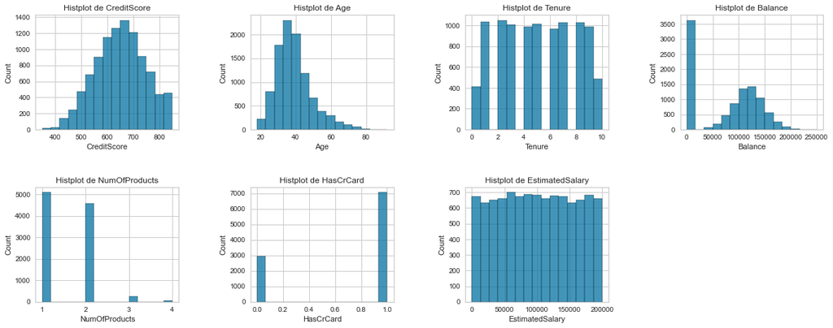

```python
# Plot

# Tamanho da figura
plt.figure(1, figsize = (20, 12))

# Inicializa contador
n = 0

# Loop pelas colunas
for x in ['CreditScore', 'Age', 'Tenure', 'Balance', 'NumOfProducts', 'HasCrCard', "EstimatedSalary"]:
    n += 1
    plt.subplot(3, 4, n)
    plt.subplots_adjust(hspace = 0.5, wspace = 0.5)
    sns.histplot(df1[x], bins = 15)
    plt.title("Histplot de {}".format(x))
plt.show()
```

#### Vamos criar um gráfico de estimativa de densidade do Kernel (**KDE**) pelo valor do alvo. KDE é uma maneira de identificar se existe uma correlação entra a variável dependente e alvo, nesse caso a correlação entre idade e churn.

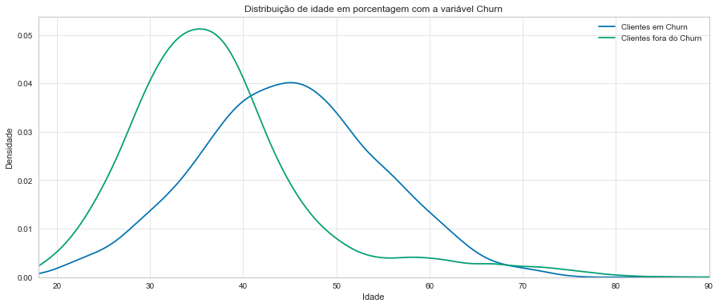

```python
# KDE plot

plt.figure(figsize = (15,6))
plt.style.use('seaborn-colorblind')
plt.grid(True, alpha = 0.5)
sns.kdeplot(df1.loc[df1['Exited'] == 1, 'Age'], label = 'Clientes em Churn')
sns.kdeplot(df1.loc[df1['Exited'] == 0, 'Age'], label = 'Clientes fora do Churn')
plt.legend()
plt.xlim(left = 18, right = 90)
plt.xlabel('Idade')
plt.ylabel('Densidade')
plt.title('Distribuição de idade em porcentagem com a variável Churn');
```

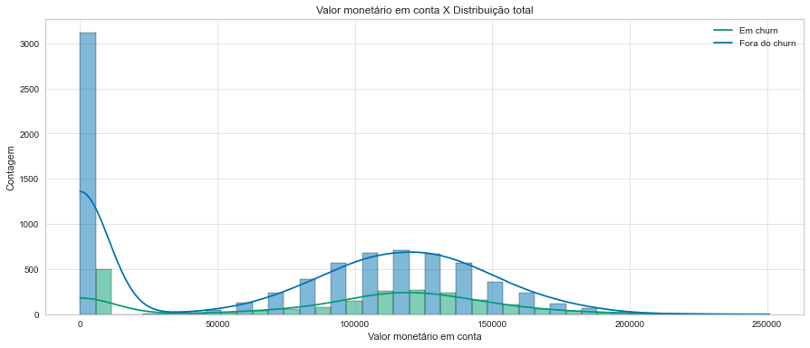

```python
# Plot do Valor monetário em conta dos clientes dentro e fora do churn

plt.figure(figsize = (15,6))
plt.style.use('seaborn-colorblind')
plt.grid(True, alpha = 0.5)
sns.histplot(data = df1, x = 'Balance', hue = 'Exited', kde = True, multiple = 'dodge')
plt.legend(['Em churn', 'Fora do churn'])
plt.xlabel('Valor monetário em conta')
plt.ylabel('Contagem')
plt.title('Valor monetário em conta X Distribuição total');
```

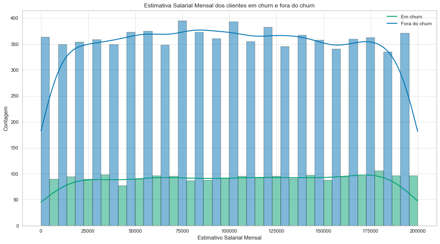

```python
# Plot do estimativa salarial mensal dos clientes dentro e fora do churn

plt.figure(figsize = (15,8))
plt.style.use('seaborn-colorblind')
plt.grid(True, alpha = 0.5)
sns.histplot(data = df1, x = 'EstimatedSalary', hue = 'Exited', kde = True, multiple = 'dodge')
plt.legend(['Em churn', 'Fora do churn'], loc = 'upper right')
plt.xlabel('Estimativo Salarial Mensal')
plt.ylabel('Contagem')
plt.title('Estimativa Salarial Mensal dos clientes em churn e fora do churn');
```

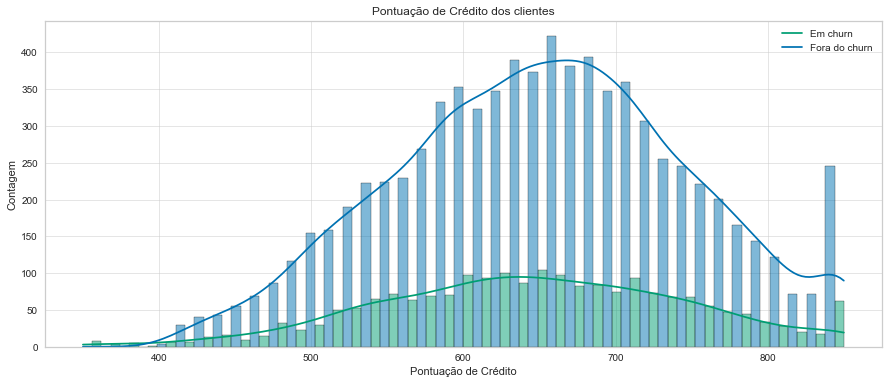

```python
# Plot do Score de Crédito dos clientes dentro e fora do churn

plt.figure(figsize = (15,6))
plt.style.use('seaborn-colorblind')
plt.grid(True, alpha = 0.5)
sns.histplot(data = df1, x = 'CreditScore', hue = 'Exited', kde = True, multiple = 'dodge')
plt.legend(['Em churn', 'Fora do churn'])
plt.xlabel('Pontuação de Crédito')
plt.ylabel('Contagem')
plt.title('Pontuação de Crédito dos clientes');
```

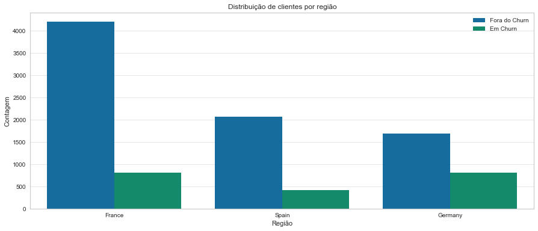

```python
# Contagem de clientes por região

plt.figure(figsize = (15,6))
plt.style.use('seaborn-colorblind')
plt.grid(True, alpha = 0.5)
sns.countplot(x = 'Geography', hue = 'Exited', data = df1)
plt.legend(labels = ['Fora do Churn', 'Em Churn'])
plt.xlabel("Região")
plt.ylabel("Contagem")
plt.title("Distribuição de clientes por região")
```

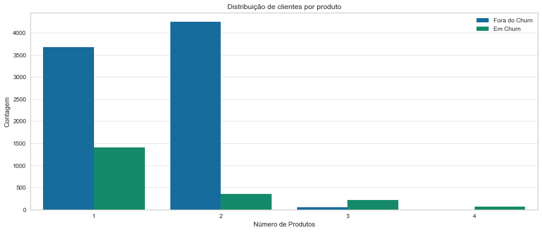

```python
# Contagem de clientes por produtos

plt.figure(figsize = (15,6))
plt.style.use('seaborn-colorblind')
plt.grid(True, alpha = 0.5)
sns.countplot(x = 'NumOfProducts', hue = 'Exited', data = df1)
plt.legend(labels = ['Fora do Churn', 'Em Churn'], loc = 'upper right')
plt.xlabel("Número de Produtos")
plt.ylabel("Contagem")
plt.title("Distribuição de clientes por produto")
```

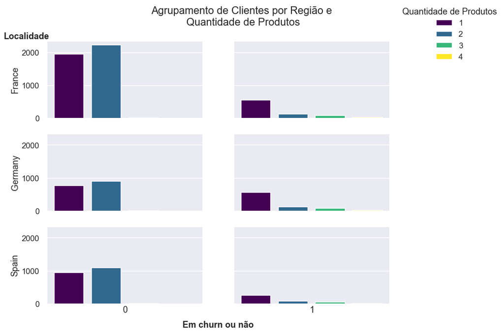

```python
from matplotlib.cm import get_cmap
from matplotlib.patches import Patch

# Criando um dataframe secundário para analisar as variáveis categoricas Geography, NumOfProducts e Exited
df2 = df1[['Geography', 'NumOfProducts', 'Exited']]
df2['Dummy'] = np.ones(len(df2))

# Agrupando pelas categorias desejadas
grouped = df2.groupby(by=['Geography','Exited','NumOfProducts' ]).count().unstack()

# Lista dos clientes em churn ou fora, para usar como categoria depois
kinds = grouped.columns.levels[1]

# Cores para o grafico
colors = [get_cmap('viridis')(v) for v in np.linspace(0,1,len(kinds))]

sns.set(context="talk")
nxplots = len(grouped.index.levels[0])
nyplots = len(grouped.index.levels[1])
fig, axes = plt.subplots(nxplots,
                         nyplots,
                         sharey=True,
                         sharex=True,
                         figsize=(15,10))

fig.suptitle('Agrupamento de Clientes por Região e \nQuantidade de Produtos')

# plot
for a, b in enumerate(grouped.index.levels[0]):
    for i, j in enumerate(grouped.index.levels[1]):
        axes[a,i].bar(kinds,grouped.loc[b,j],color=colors)
        axes[a,i].xaxis.set_ticks([])

axeslabels = fig.add_subplot(111, frameon=False)
plt.tick_params(labelcolor='none', top=False, bottom=False, left=False, right=False)
plt.grid(False)
axeslabels.set_ylabel('Localidade',rotation='horizontal',y=1,weight="bold")
axeslabels.set_xlabel('Em churn ou não',weight="bold")

# Rotulos dos eixo X e Y
for i, j in enumerate(grouped.index.levels[1]):
    axes[nyplots,i].set_xlabel(j)
for i, j in enumerate(grouped.index.levels[0]):
    axes[i,0].set_ylabel(j)

# Ajuste manual para abrir espaço para a legenda
fig.subplots_adjust(right=0.78)

fig.legend([Patch(facecolor = i) for i in colors],
           kinds,
           title="Quantidade de Produtos",
           loc="upper right")
```

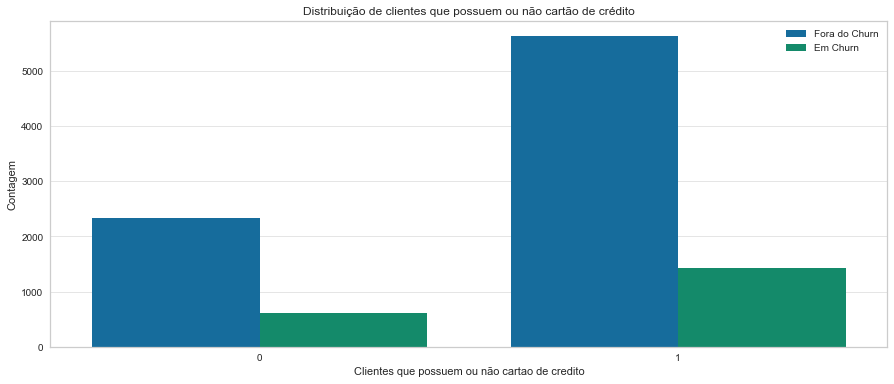

```python
# Contagem por clientes que tem ou não cartao de credito

plt.figure(figsize = (15,6))
plt.style.use('seaborn-colorblind')
plt.grid(True, alpha = 0.5)
sns.countplot(x = 'HasCrCard', hue = 'Exited', data = df1)
plt.legend(labels = ['Fora do Churn' , 'Em Churn'])
plt.xlabel("Clientes que possuem ou não cartao de credito")
plt.ylabel("Contagem")
plt.title("Distribuição de clientes que possuem ou não cartão de crédito")
```

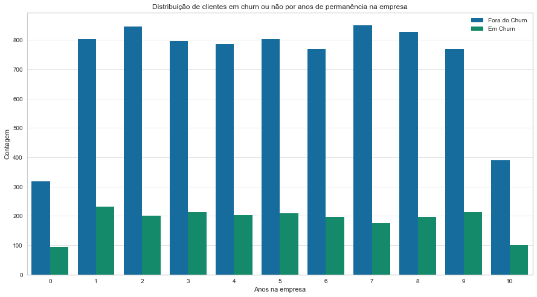

```python
# Distribuição de clientes por tempo de empresa fora do churn

plt.figure(figsize = (15,8))
plt.style.use('seaborn-colorblind')
plt.grid(True, alpha = 0.5)
sns.countplot(x = 'Tenure', hue = 'Exited', data = df1)
plt.legend(labels = ['Fora do Churn' , 'Em Churn'])
plt.xlabel("Anos na empresa")
plt.ylabel("Contagem")
plt.title("Distribuição de clientes em churn ou não por anos de permanência na empresa")
```

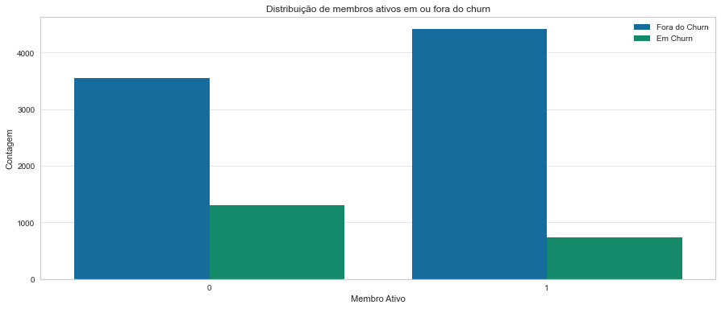

```python
# Distribuição de clientes que fazem movimentação na conta num período de 12 meses em ou fora do churn

plt.figure(figsize = (15,6))
plt.style.use('seaborn-colorblind')
plt.grid(True, alpha = 0.5)
sns.countplot(x = 'IsActiveMember', hue = 'Exited',data = df1)
plt.legend(['Fora do Churn' , 'Em Churn'])
plt.xlabel("Membro Ativo")
plt.ylabel("Contagem")
plt.title("Distribuição de membros ativos em ou fora do churn")
```

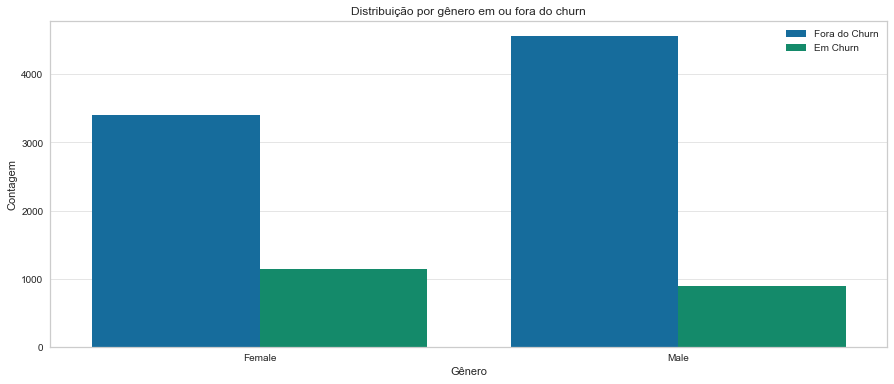

```python
# Distribuição de clientes por genero em ou fora do churn

plt.figure(figsize = (15,6))
plt.style.use('seaborn-colorblind')
plt.grid(True, alpha = 0.5)
sns.countplot(x = 'Gender', hue = 'Exited',data = df1)
plt.legend(labels = ['Fora do Churn' , 'Em Churn'])
plt.xlabel("Gênero")
plt.ylabel("Contagem")
plt.title("Distribuição por gênero em ou fora do churn")
```

Após a Análise Exploratória dos dados, vamos verificar abaixo alguns insights para o problema proposto.

# Insights do problema de negócio

[figure not shown]

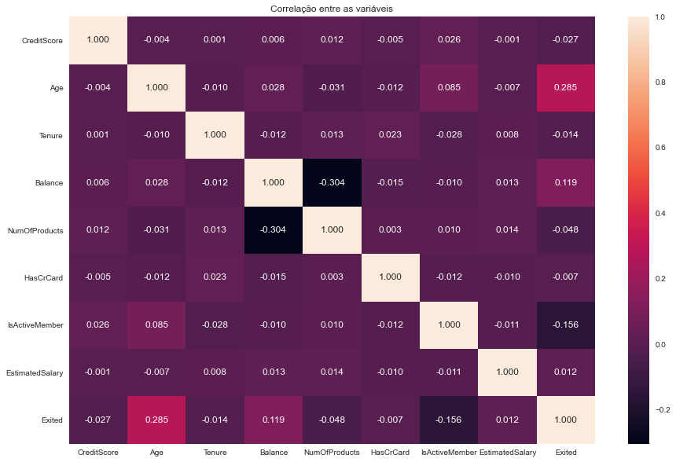

```python
# Gerando plot de correlação entre as variáveis

# Armazenando correlação do dataframe
corr = df1.corr()

# Gerando corrplot
plt.figure(figsize = (15,10))
sns.heatmap(corr, annot = True, fmt = '.3f')
plt.title("Correlação entre as variáveis")
plt.show()
```

```python
# Proporção entre clientes em churn ou não
(df1['Exited'].value_counts()/len(df1['Exited']))*100
```

```
0    79.63
1    20.37
Name: Exited, dtype: float64
```

Através do código acima vimos que há um desbalanceamento dos dados na variável alvo (Exited, o que pode enviesar o modelo e atrapalhar nas decisões futuras). Vamos Utilizar o PyCaret, uma ferramenta completa que consegue treinar o dataset com vários modelos, mostrar as diferentes métricas de desempenho para cada um deles, tunar o modelo escolhido e mostrar todo esse resultado.

```python
# Configurando o modelo para o dataset
s = setup(df1, target = "Exited", fix_imbalance = True)
```

|  | Description | Value |
| --- | --- | --- |
| 0 | session_id | 1523 |
| 1 | Target | Exited |
| 2 | Target Type | Binary |
| 3 | Label Encoded | None |
| 4 | Original Data | (10000, 11) |
| 5 | Missing Values | False |
| 6 | Numeric Features | 4 |
| 7 | Categorical Features | 6 |
| 8 | Ordinal Features | False |
| 9 | High Cardinality Features | False |
| 10 | High Cardinality Method | None |
| 11 | Transformed Train Set | (6999, 25) |
| 12 | Transformed Test Set | (3001, 25) |
| 13 | Shuffle Train-Test | True |
| 14 | Stratify Train-Test | False |
| 15 | Fold Generator | StratifiedKFold |
| 16 | Fold Number | 10 |
| 17 | CPU Jobs | -1 |
| 18 | Use GPU | False |
| 19 | Log Experiment | False |
| 20 | Experiment Name | clf-default-name |
| 21 | USI | 4afd |
| 22 | Imputation Type | simple |
| 23 | Iterative Imputation Iteration | None |
| 24 | Numeric Imputer | mean |
| 25 | Iterative Imputation Numeric Model | None |
| 26 | Categorical Imputer | constant |
| 27 | Iterative Imputation Categorical Model | None |
| 28 | Unknown Categoricals Handling | least_frequent |
| 29 | Normalize | False |
| 30 | Normalize Method | None |
| 31 | Transformation | False |
| 32 | Transformation Method | None |
| 33 | PCA | False |
| 34 | PCA Method | None |
| 35 | PCA Components | None |
| 36 | Ignore Low Variance | False |
| 37 | Combine Rare Levels | False |
| 38 | Rare Level Threshold | None |
| 39 | Numeric Binning | False |
| 40 | Remove Outliers | False |
| 41 | Outliers Threshold | None |
| 42 | Remove Multicollinearity | False |
| 43 | Multicollinearity Threshold | None |
| 44 | Remove Perfect Collinearity | True |
| 45 | Clustering | False |
| 46 | Clustering Iteration | None |
| 47 | Polynomial Features | False |
| 48 | Polynomial Degree | None |
| 49 | Trignometry Features | False |
| 50 | Polynomial Threshold | None |
| 51 | Group Features | False |
| 52 | Feature Selection | False |
| 53 | Feature Selection Method | classic |
| 54 | Features Selection Threshold | None |
| 55 | Feature Interaction | False |
| 56 | Feature Ratio | False |
| 57 | Interaction Threshold | None |
| 58 | Fix Imbalance | True |
| 59 | Fix Imbalance Method | SMOTE |

Vamos rankear e selecionar o melhor modelo de acordo com a métrica AUC.

```python
# Comparando todos os modelos
best_model = compare_models(sort = 'AUC')
```

[output not shown]

```python
# Print dos parametros do melhor modelo
print(best_model)
```

```
GradientBoostingClassifier(ccp_alpha=0.0, criterion='friedman_mse', init=None,
                           learning_rate=0.1, loss='deviance', max_depth=3,
                           max_features=None, max_leaf_nodes=None,
                           min_impurity_decrease=0.0, min_impurity_split=None,
                           min_samples_leaf=1, min_samples_split=2,
                           min_weight_fraction_leaf=0.0, n_estimators=100,
                           n_iter_no_change=None, presort='deprecated',
                           random_state=1523, subsample=1.0, tol=0.0001,
                           validation_fraction=0.1, verbose=0,
                           warm_start=False)
```

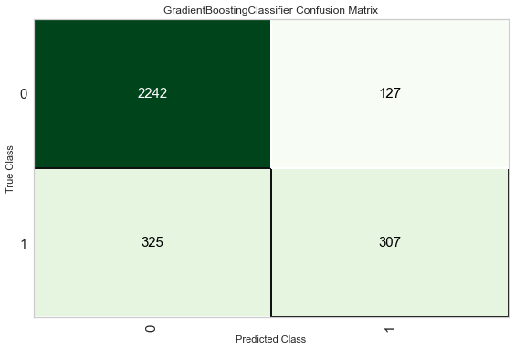

```python
# Confusion matrix do modelo sem melhorias
plot_model(best_model, plot = 'confusion_matrix')
```

A Confusion Matrix acompanha o conjunto de teste, um split de 70/30: 70% do dataset utilizado para treino e 30% para teste.

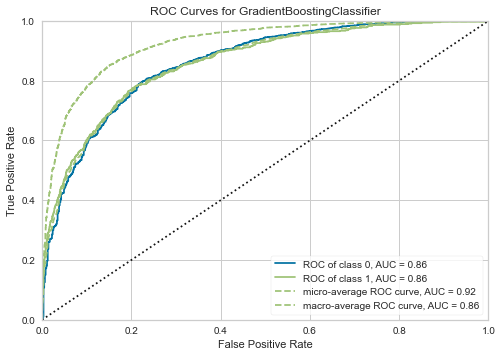

```python
# plot AUC do melhor modelo original
plot_model(best_model, plot = 'auc')
```

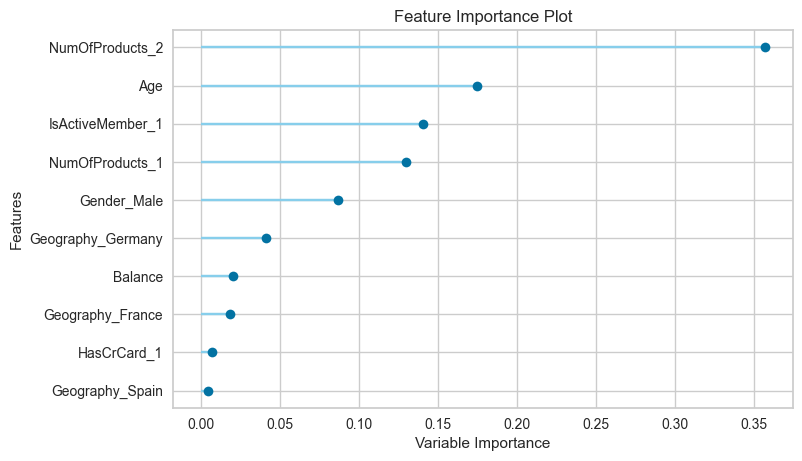

```python
# Plot das variáveis mais relevantes
plot_model(best_model, plot = 'feature')
```

Nós vamos utilizar de uma função do PyCaret para automaticamente tunar os hiperparâmetros do modelo, afim de trazer um melhor resultado diante as métricas observadas.

```python
# Tunando o melhor modelo
tuned_best_model = tune_model(best_model)
```

[output not shown]

#### O modelo teve uma melhoria de apenas 0,01%, porém muda na quantidade de Verdadeiros Positivos de forma razoável, influenciando no resultado final.

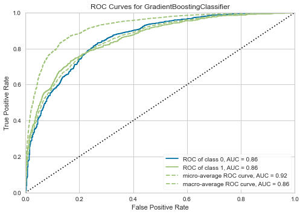

```python
# Plot AUC do melhor modelo tunado
plot_model(tuned_best_model, plot = 'auc')
```

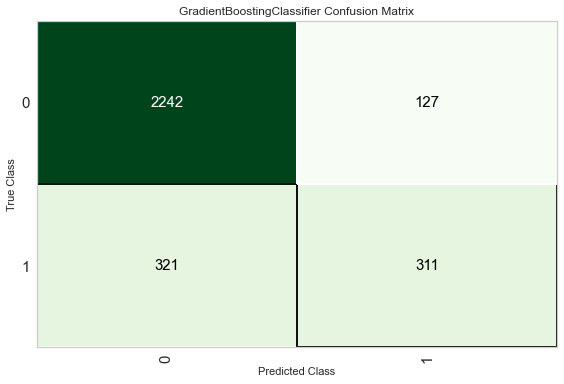

```python
# Confusion matrix do modelo sem melhorias
plot_model(tuned_best_model, plot = 'confusion_matrix')
```

Com a melhoria do modelo temos as seguintes informações:

- Dos 3000 clientes temos agora 311 Verdadeiros Positivo - Para os quais podemos oferecer alguma promoção;
- Manteve a quantidade de Falsos positivos, onde seria o público para quem perderíamos dinheiro, identificados como clientes em Churn porém não são verdadeiramente;
- E uma diminuição para 321 clientes Falsos Negativo, clientes que entrariam em Churn porém não seriam identificados como tal.

Num problema de negócio como esse de rotatividade de cliente, o retorno financeiro dos verdadeiros positivos é diferente do custo dos falsos positivos. Vamos concretizar essa teoria com as seguintes posições:

- Oferecer um voucher de R$1000,00 a todos os clientes identificados como churn (Verdadeiro Positivo + Falso Positivo);
- Se interrompermos o churn, ganhamos R$5000,00 em valor de permanência do cliente na empresa.

### Com a suposições acima e os valores da Confusion Matrix, vamos calcular o impacto financeiro desse modelo:

[figure not shown]

### Com o PyCaret conseguimos adicionar uma nova métrica que vai de acordo com o problema proposto. Para isso vamos criar uma métrica de lucro, que é o que queremos aumentar no final de avaliação de churn.

```python
# Cria uma função personalizada
def calcula_profit(y, y_pred):
    tp = np.where((y_pred == 1) & (y == 1), (5000-1000), 0)
    fp = np.where((y_pred == 1) & (y == 0), -1000, 0)
    return np.sum([tp,fp])

# Adiciona metrica ao PyCaret
add_metric('profit', 'Profit', calcula_profit)
```

```
Name                                                          Profit
Display Name                                                  Profit
Score Function       <function calcula_profit at 0x0000026664AFFB70>
Scorer                                   make_scorer(calcula_profit)
Target                                                          pred
Args                                                              {}
Greater is Better                                               True
Multiclass                                                      True
Custom                                                          True
Name: profit, dtype: object
```

```python
# Agora vamos comparar os modelos com a nova métrica
best_model_profit = compare_models(sort = 'Profit')
```

|  | Model | Accuracy | AUC | Recall | Prec. | F1 | Kappa | MCC | Profit | TT (Sec) |
| --- | --- | --- | --- | --- | --- | --- | --- | --- | --- | --- |
| lda | Linear Discriminant Analysis | 0.7664 | 0.8326 | 0.7409 | 0.4507 | 0.5600 | 0.4137 | 0.4378 | 289300.0000 | 0.0830 |
| ridge | Ridge Classifier | 0.7663 | 0.0000 | 0.7409 | 0.4505 | 0.5599 | 0.4135 | 0.4376 | 289200.0000 | 0.0350 |
| gbc | Gradient Boosting Classifier | 0.8600 | 0.8652 | 0.5260 | 0.7025 | 0.6009 | 0.5182 | 0.5265 | 264200.0000 | 1.2550 |
| lightgbm | Light Gradient Boosting Machine | 0.8650 | 0.8588 | 0.5110 | 0.7357 | 0.6020 | 0.5241 | 0.5373 | 261400.0000 | 0.5660 |
| ada | Ada Boost Classifier | 0.8463 | 0.8431 | 0.5409 | 0.6400 | 0.5852 | 0.4918 | 0.4951 | 260900.0000 | 0.3740 |
| xgboost | Extreme Gradient Boosting | 0.8577 | 0.8511 | 0.5110 | 0.7003 | 0.5900 | 0.5065 | 0.5162 | 256300.0000 | 2.2940 |
| rf | Random Forest Classifier | 0.8614 | 0.8558 | 0.5017 | 0.7236 | 0.5917 | 0.5117 | 0.5246 | 255000.0000 | 0.8360 |
| et | Extra Trees Classifier | 0.8520 | 0.8430 | 0.4840 | 0.6860 | 0.5669 | 0.4810 | 0.4920 | 240900.0000 | 0.9450 |
| dt | Decision Tree Classifier | 0.8023 | 0.7021 | 0.5346 | 0.5070 | 0.5196 | 0.3954 | 0.3962 | 227400.0000 | 0.0600 |
| nb | Naive Bayes | 0.6817 | 0.7565 | 0.7302 | 0.3576 | 0.4799 | 0.2878 | 0.3258 | 225500.0000 | 0.0340 |
| lr | Logistic Regression | 0.6661 | 0.7172 | 0.6740 | 0.3369 | 0.4486 | 0.2466 | 0.2770 | 190900.0000 | 1.0590 |
| svm | SVM - Linear Kernel | 0.5047 | 0.0000 | 0.5776 | 0.1563 | 0.2446 | 0.0346 | 0.0589 | 37500.0000 | 0.2220 |
| knn | K Neighbors Classifier | 0.5687 | 0.5204 | 0.4150 | 0.2096 | 0.2784 | 0.0162 | 0.0182 | 13500.0000 | 0.1590 |
| qda | Quadratic Discriminant Analysis | 0.7993 | 0.0000 | 0.0000 | 0.0000 | 0.0000 | 0.0000 | 0.0000 | 0.0000 | 0.0470 |
| dummy | Dummy Classifier | 0.7993 | 0.5000 | 0.0000 | 0.0000 | 0.0000 | 0.0000 | 0.0000 | 0.0000 | 0.0410 |

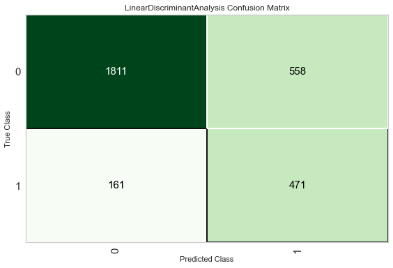

```python
# Confusion Matrix LDA
plot_model(best_model_profit, plot = 'confusion_matrix')
```

Acontece que agora o modelo aumentou tanto os valores de Verdadeiros Positivos e Falsos Positivos, e isso é relevante para nosso caso porque estamos focados em entregar produtos para quem o modelo irá prever que estará em Churn, tanto os Verdadeiros Positivos como Falsos Positivos. Agora vamos aplicar as mesmas suposições que comentei logo antes:

[figure not shown]

### Na versão 2.3.6 do PyCaret houve também muita coisa nova, como o deploy do modelo de forma bastante prática.

#### É possível criar um app apenas com uma linha de código. Com base na biblioteca Gradio, cria-se um web app em que você pode inserir os valores das variáveis independentes e o app informa o resultado previsto. Vamos conferir abaixo.

```python
# Cria o app
create_app(best_model_profit)
```

[figure not shown]

# Chegamos ao fim de um Projeto de Churn de clientes, com insights, avaliações de modelos preditivos, métricas, resultado financeiro e aplicação web de todo esse estudo de caso.

**Contato:**

- matheus131998@gmail.com
- https://www.linkedin.com/in/matheus-oliveira-064242129/